# Tutorial: Calculating Taxonomic (tNICE) and Functional (fNICE) Metrics

Lucie Kuczynski

January 07, 2025

# Introduction

In this tutorial we will illustrate how to compute both following metrics:

- **tNICE**: taxonomic Net Imbalance between Colonisations and Extinctions
- **fNICE**: functional Net Imbalance between Colonisations and Extinctions

## About the Metrics

The **taxonomic Net Immigration-Extinction metric** (tNICE) examines the balance of species gains (colonizations) vs. species losses (extinctions) over time, strictly focusing on the identity (i.e., presence/absence) of species. If more species appear than disappear over time, tNICE tends to be positive; if more disappear, it tends to be negative. The **functional Net Immigration-Extinction metric** (fNICE) focuses on the trait space occupied by the community. It measures how much functional volume is gained vs. lost between consecutive time points, using methods like convex hulls in a multivariate trait space. This highlights whether the community is expanding or contracting in terms of functional niches.

More details can be found in the following two publications: [Kuczynski *et al.* (2023)](https://www.nature.com/articles/s41559-023-02078-w) and [Kuczynski *et al.* (2024)](https://besjournals.onlinelibrary.wiley.com/doi/full/10.1111/1365-2435.14599).

We will use a data set with three sites from the Wadden Sea which have been separated into three subsets each composed of three components:

- A community matrix (`com`) with rows as time points and columns as species.
- A trait table (`traits`) with one row per species and several trait columns.
- A small metadata table (`infos`) describing each site.

We assume two functions are already available in your environment:

`compute_tNICE(com, infos)` `compute_fNICE(com, infos, traits)` Both rely on some or all of these additional functions: `OLE()`, `complementary_volume()`, etc.

Under the hood, these scripts do the following:

- `compute_tNICE()`:
1. Identifies species colonizations and extinctions by applying an Optimal Linear Estimator (OLE) on the forward (extinction) and reversed (colonization) timeline.
2. Sums up the events to get cumulative colonizations (COL) and extinctions (EXT) for each year.
3. Calculates NICE = (COL − EXT) / (COL + EXT) , which reflects net changes in species over time.
- `compute_fNICE()`:
1. Computes a Gower distance matrix on the given species traits, then applies PCoA.
2. Builds convex hulls in the resulting multivariate trait space for each time point.
3. Estimates how much functional space is lost/gained between consecutive sampling periods (via convex hull intersections).
4. Calculates a net imbalance (fNICE) as the difference between total gained and lost volumes over time.

# Compute tNICE

## Site A

```r
# Compute tNICE for Site A
out_tA <- compute_tNICE(com = comA, infos = infosA)

# Inspect the output structure
summary(out_tA)
```

```
##       YEAR           COL         EXT             NICE          SR
##  Min.   :1997   Min.   :0   Min.   : 0.00   Min.   :-1   Min.   :27.00
##  1st Qu.:2002   1st Qu.:0   1st Qu.: 0.00   1st Qu.:-1   1st Qu.:39.00
##  Median :2006   Median :0   Median : 0.00   Median :-1   Median :44.00
##  Mean   :2007   Mean   :0   Mean   : 2.56   Mean   :-1   Mean   :43.64
##  3rd Qu.:2012   3rd Qu.:0   3rd Qu.: 0.00   3rd Qu.:-1   3rd Qu.:48.00
##  Max.   :2016   Max.   :0   Max.   :56.00   Max.   :-1   Max.   :60.00
##                                             NA's   :68
```

Typically, the returned data frame (`out_tA`) includes columns:

- `YEAR`: the sampled years
- `COL`: cumulative colonizations
- `EXT`: cumulative extinctions
- `NICE`: net ratio (COL - EXT) / (COL + EXT)
- `SR`: species richness at each time point

We can extract the **final** tNICE value (i.e., the most recent year):

```r
tNICE_final_A <- out_tA$NICE[nrow(out_tA)]
tNICE_final_A
```

```
## [1] -1
```

## Sites B and C

```r
# Compute tNICE for Site B
out_tB <- compute_tNICE(com = comB, infos = infosB)

# Final tNICE
if (!is.null(out_tB)) {
  tNICE_final_B <- out_tB$NICE[nrow(out_tB)]
} else {
  tNICE_final_B <- NA
}
tNICE_final_B
```

```
## [1] -1
```

```r
# Compute tNICE for Site C
out_tC <- compute_tNICE(com = comC, infos = infosC)

# Final tNICE
if (!is.null(out_tC)) {
  tNICE_final_C <- out_tC$NICE[nrow(out_tC)]
} else {
  tNICE_final_C <- NA
}
tNICE_final_C
```

```
## [1] 0.3333333
```

# Compute fNICE

## Site A

```r
# Compute fNICE for Site A
out_fA <- compute_fNICE(com = comA, infos = infosA, traits = traitsA)
```

```
## [1] "0 species removed due to missing trait values"
```

```r
# The final metric is typically in $fNICE_cum$fNICE.obs (or similar naming)
if (!is.null(out_fA)) {
  fNICE_final_A <- out_fA$fNICE_cum$fNICE.obs[nrow(out_fA$fNICE_cum)]
} else {
  fNICE_final_A <- NA
}
fNICE_final_A
```

```
## [1] -7.681745e-10
```

## Sites B and C

```r
# Compute fNICE for Site B
out_fB <- compute_fNICE(com = comB, infos = infosB, traits = traitsB)
```

```
## [1] "0 species removed due to missing trait values"
```

```r
if (!is.null(out_fB)) {
  fNICE_final_B <- out_fB$fNICE_cum$fNICE.obs[nrow(out_fB$fNICE_cum)]
} else {
  fNICE_final_B <- NA
}
fNICE_final_B
```

```
## [1] 8.785574e-09
```

```r
# Compute fNICE for Site C
out_fC <- compute_fNICE(com = comC, infos = infosC, traits = traitsC)
```

```
## [1] "0 species removed due to missing trait values"
```

```r
if (!is.null(out_fC)) {
  fNICE_final_C <- out_fC$fNICE_cum$fNICE.obs[nrow(out_fC$fNICE_cum)]
} else {
  fNICE_final_C <- NA
}
fNICE_final_C
```

```
## [1] 3.632727e-06
```

# Summarize and plot

Now we have **final tNICE** and **fNICE** values for each site. We also want each site’s time-series length—we will derive it from the row count in the com matrices rather than using any hard-coded constants.

```r
# 1. Create a data frame that summarizes all final values
df_summary <- data.frame(
  Site             = c("comA", "comB", "comC"),
  TimeSeriesLength = c(nrow(comA), nrow(comB), nrow(comC)),  # derived from com
  tNICE_final      = c(tNICE_final_A, tNICE_final_B, tNICE_final_C),
  fNICE_final      = c(fNICE_final_A, fNICE_final_B, fNICE_final_C)
)

df_summary
```

```
##   Site TimeSeriesLength tNICE_final   fNICE_final
## 1 comA               75  -1.0000000 -7.681745e-10
## 2 comB               43  -1.0000000  8.785574e-09
## 3 comC               11   0.3333333  3.632727e-06
```

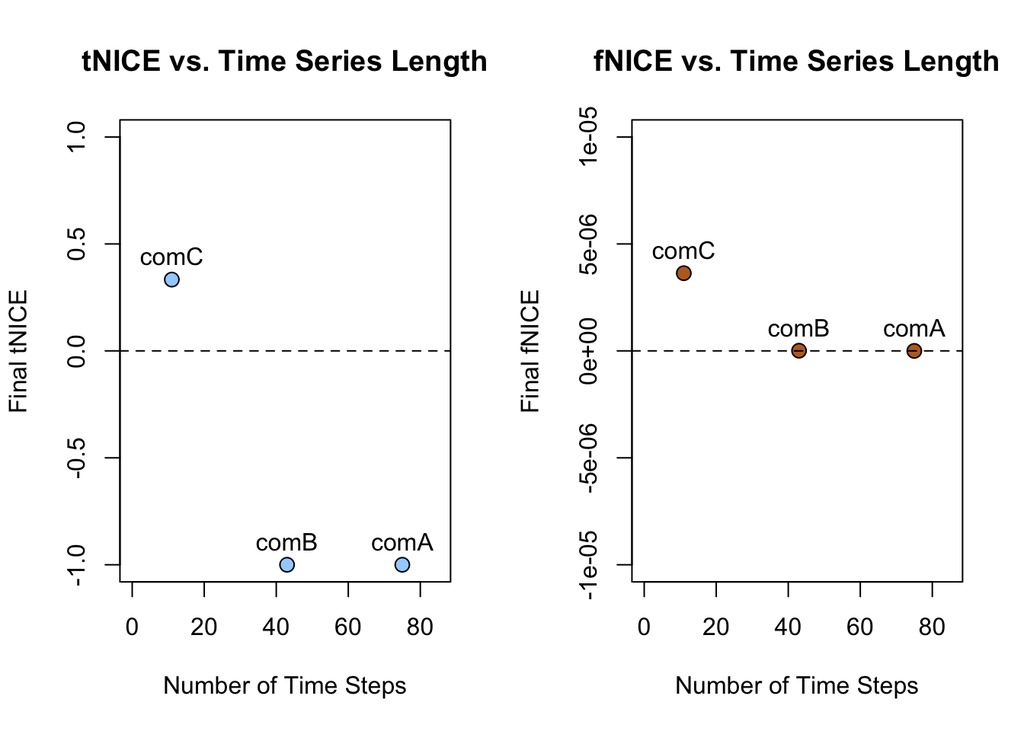

```r
par(mfrow = c(1,2))  # 2 plots side-by-side

# Plot tNICE vs. number of time steps
plot(
  df_summary$TimeSeriesLength, df_summary$tNICE_final,
  xlab = "Number of Time Steps", ylab = "Final tNICE",
  ylim = c(-1, 1), xlim = c(0, 85),
  pch = 21, bg = "#a2d2ff", cex = 1.3, main = "tNICE vs. Time Series Length")
abline(h = 0, lty = 2)
text(
  df_summary$TimeSeriesLength, df_summary$tNICE_final,
  labels = df_summary$Site, pos = 3)

# Plot fNICE vs. number of time steps
plot(
  df_summary$TimeSeriesLength, df_summary$fNICE_final,
  xlab = "Number of Time Steps", ylab = "Final fNICE",
  ylim = c(-1e-5, 1e-5), xlim = c(0, 85),
  pch = 21, bg = "#bc6c25", cex = 1.3, main = "fNICE vs. Time Series Length")
abline(h = 0, lty = 2)
text(
  df_summary$TimeSeriesLength, df_summary$fNICE_final,
  labels = df_summary$Site, pos = 3)
```

From these two plots, you can see how the most recent tNICE and fNICE metric values vary across the three sites with different lengths of time series and different community structures.